# A report on the cumulative confirmed cases of Ebola in selected West African Countries from October 2015 to March 2016

- Show All Code
- Hide All Code
- View Source

Author

Samuel G. Okech

Published

April 24, 2024

```r
# Load libraries
library(here)
library(tidyverse)
library(lubridate)
library(unibeCols)
```

## Data

```r
# Read data
cases <- read_csv(here("data/raw/ebola.csv"))
str(cases)
```

I want to select some West African countries

```r
cases_2 <- cases |> mutate (across(c(Country), factor))
    # region = factor(region))
```

```r
str(cases_2)
```

```
tibble [2,484 × 6] (S3: tbl_df/tbl/data.frame)
 $ ...1          : num [1:2484] 1 2 3 4 5 6 7 8 9 10 ...
 $ Country       : Factor w/ 12 levels "Guinea","Guinea 2",..: 1 4 9 11 6 7 8 10 12 11 ...
 $ Date          : chr [1:2484] "10/03/2015" "10/03/2015" "10/03/2015" "10/03/2015" ...
 $ Cum_conf_cases: num [1:2484] 2871 3150 8428 1 7 ...
 $ Cum_susp_cases: num [1:2484] 22 4314 2904 0 0 ...
 $ Cum_conf_death: num [1:2484] 1778 NA 3263 NA NA ...
```

```r
cases_African <- cases_2 %>% filter(Country %in% c("Guinea", "Liberia", "Sierra Leone", "Mali"))
```

## Visualisation

Figure 1 shows the cumulative number of confirmed Ebola cases in selected West African countries from October 2015 to March 2016

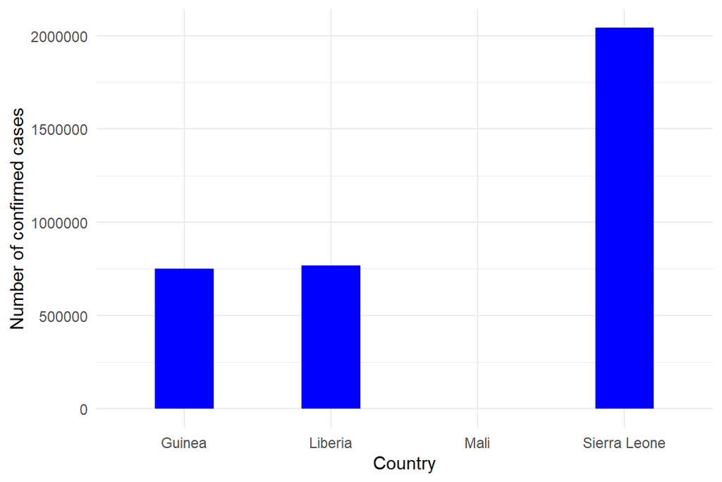

Figure 1: Confirmed cases of Ebola in selected West African countries from October 2015 to March 2016.

```r
ggplot(data = cases_African, mapping = aes(x = Country, y = Cum_conf_cases)) +
  geom_col(position = "stack", alpha = 1.0, fill = "blue", linetype = "solid", linewidth = 0.5, width = 0.4) +labs(x = "Country", y = "Number of confirmed cases") +
  theme_minimal()
```

Figure 2 shows the cumulative number of suspected Ebola cases in selected West African countries from October 2015 to March 2016

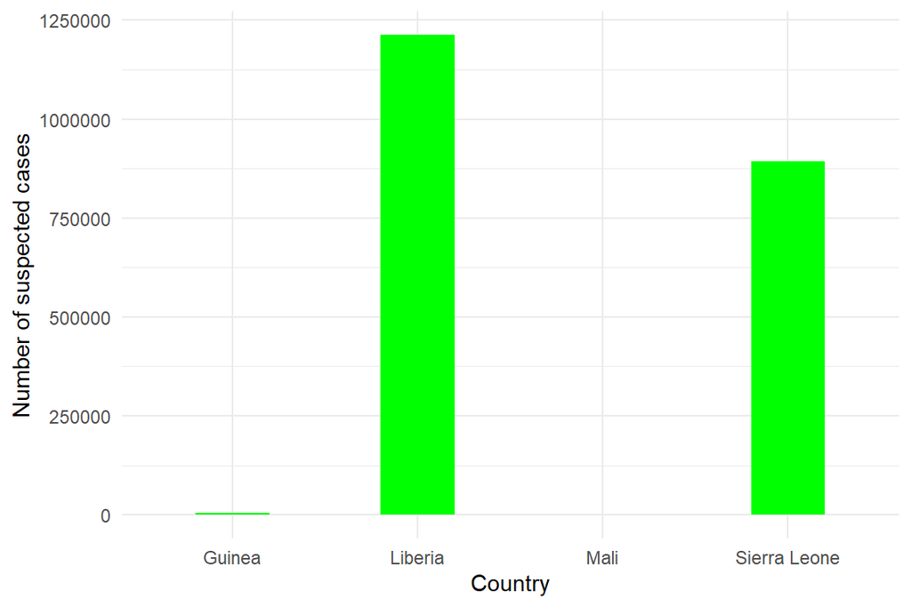

Figure 2: Suspected cases of Ebola in selected West African countries from October 2015 to March 2016.

```r
ggplot(data = cases_African, mapping = aes(x = Country, y = Cum_susp_cases)) +
  geom_col(position = "stack", alpha = 1.0, fill = "green", linetype = "solid", linewidth = 0.5, width = 0.4) +labs(x = "Country", y = "Number of suspected cases") +
  theme_minimal()
```

Figure 3 shows the cumulative number of deaths from Ebola in selected West African countries from October 2015 to March 2016

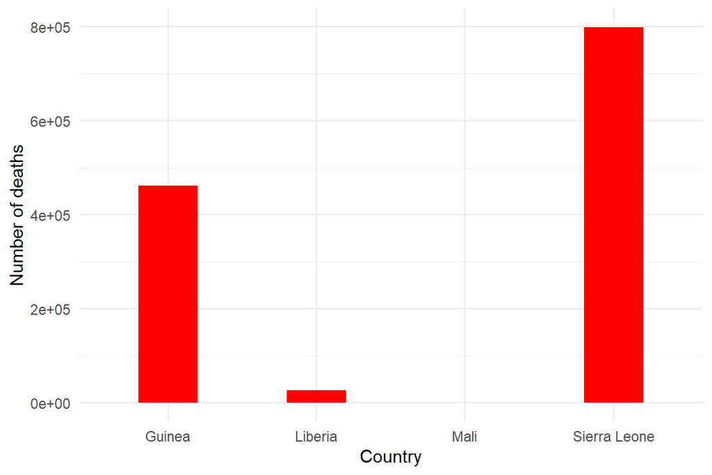

Figure 3: Deaths from Ebola in selected West African countries from October 2015 to March 2016.

```r
ggplot(data = cases_African, mapping = aes(x = Country, y = Cum_conf_death)) +
  geom_col(position = "stack", alpha = 1.0, fill = "red", linetype = "solid", linewidth = 0.5, width = 0.4) +labs(x = "Country", y = "Number of deaths") +
  theme_minimal()
```

## Conclusion

During the period of surveillance, Sierra Leone reported more than twice the number of confirmed cases of Ebola than Guinea and Liberia. Consequently, more deaths were reported in Sierra Leone than the other two countries.

## Acknowledgement

I give special appreciation to the team at ISPM University of Bern, led by Prof. Christian Althaus for the support rendered in the production of this report.